# Problem Set 4

## 1.1

### 1.

```python
import pandas as pd
import numpy as np
import matplotlib.pyplot as plt
```

```python
wisc = pd.read_csv("../data/wdbc.csv.bz2")
wisc = wisc.drop("id",axis=1)
wisc.head()
```

|  | diagnosis | radius.mean | texture.mean | perimeter.mean | area.mean | smoothness.mean | compactness.mean | concavity.mean | concpoints.mean | symmetry.mean | ... | radius.worst | texture.worst | perimeter.worst | area.worst | smoothness.worst | compactness.worst | concavity.worst | concpoints.worst | symmetry.worst | fracdim.worst |
| --- | --- | --- | --- | --- | --- | --- | --- | --- | --- | --- | --- | --- | --- | --- | --- | --- | --- | --- | --- | --- | --- |
| 0 | M | 17.99 | 10.38 | 122.80 | 1001.0 | 0.11840 | 0.27760 | 0.3001 | 0.14710 | 0.2419 | ... | 25.38 | 17.33 | 184.60 | 2019.0 | 0.1622 | 0.6656 | 0.7119 | 0.2654 | 0.4601 | 0.11890 |
| 1 | M | 20.57 | 17.77 | 132.90 | 1326.0 | 0.08474 | 0.07864 | 0.0869 | 0.07017 | 0.1812 | ... | 24.99 | 23.41 | 158.80 | 1956.0 | 0.1238 | 0.1866 | 0.2416 | 0.1860 | 0.2750 | 0.08902 |
| 2 | M | 19.69 | 21.25 | 130.00 | 1203.0 | 0.10960 | 0.15990 | 0.1974 | 0.12790 | 0.2069 | ... | 23.57 | 25.53 | 152.50 | 1709.0 | 0.1444 | 0.4245 | 0.4504 | 0.2430 | 0.3613 | 0.08758 |
| 3 | M | 11.42 | 20.38 | 77.58 | 386.1 | 0.14250 | 0.28390 | 0.2414 | 0.10520 | 0.2597 | ... | 14.91 | 26.50 | 98.87 | 567.7 | 0.2098 | 0.8663 | 0.6869 | 0.2575 | 0.6638 | 0.17300 |
| 4 | M | 20.29 | 14.34 | 135.10 | 1297.0 | 0.10030 | 0.13280 | 0.1980 | 0.10430 | 0.1809 | ... | 22.54 | 16.67 | 152.20 | 1575.0 | 0.1374 | 0.2050 | 0.4000 | 0.1625 | 0.2364 | 0.07678 |

5 rows × 31 columns

### 2.

```python
mm = wisc.describe().loc[['min','max']]
mm
```

|  | radius.mean | texture.mean | perimeter.mean | area.mean | smoothness.mean | compactness.mean | concavity.mean | concpoints.mean | symmetry.mean | fracdim.mean | ... | radius.worst | texture.worst | perimeter.worst | area.worst | smoothness.worst | compactness.worst | concavity.worst | concpoints.worst | symmetry.worst | fracdim.worst |
| --- | --- | --- | --- | --- | --- | --- | --- | --- | --- | --- | --- | --- | --- | --- | --- | --- | --- | --- | --- | --- | --- |
| min | 6.981 | 9.71 | 43.79 | 143.5 | 0.05263 | 0.01938 | 0.0000 | 0.0000 | 0.106 | 0.04996 | ... | 7.93 | 12.02 | 50.41 | 185.2 | 0.07117 | 0.02729 | 0.000 | 0.000 | 0.1565 | 0.05504 |
| max | 28.110 | 39.28 | 188.50 | 2501.0 | 0.16340 | 0.34540 | 0.4268 | 0.2012 | 0.304 | 0.09744 | ... | 36.04 | 49.54 | 251.20 | 4254.0 | 0.22260 | 1.05800 | 1.252 | 0.291 | 0.6638 | 0.20750 |

2 rows × 30 columns

### 3.

More of the data shows benign, so the accruacy would be around 60%.

## 1.2

### 1.

a.

```python
from sklearn.neighbors import KNeighborsClassifier
```

```python
X = wisc[['texture.mean','concpoints.mean']].values
y = wisc.diagnosis.values
m = KNeighborsClassifier(7)
_ = m.fit(X,y)
```

b.

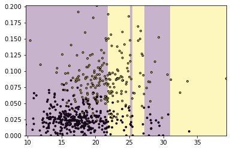

```python
def dbplot(j,i,z):
    y = wisc.diagnosis == "M"
    X = np.column_stack((j, i))
    m = KNeighborsClassifier(z)
    e = m.fit(X, y)
    ex1 = np.linspace(j.min(), j.max(), 100)
    ex2 = np.linspace(i.min(), i.min(), 100)
    xx1, xx2 = np.meshgrid(ex1, ex2)
    g = np.column_stack((xx1.ravel(), xx2.ravel()))
    haty = m.predict(g).reshape(100,100)
    _=plt.imshow(haty, extent=(j.min(), j.max(), i.min(), i.max()),
                 aspect = "auto",
                 interpolation="none", origin="lower",
                 alpha=0.3)
    _ = plt.scatter(j,i,c=y, edgecolor="k", s=8)
    _ = plt.show()
dbplot(wisc['texture.mean'], wisc['concpoints.mean'], 7)
```

c.

```python
from sklearn.model_selection import cross_val_score
X = wisc[['texture.mean','concpoints.mean']].values
y = wisc.diagnosis.values
cv = cross_val_score(m, X, y, cv=10)
cv.mean()
```

```
0.7114974937343359
```

### 2.

```python
X = wisc[['texture.mean','concpoints.mean']].values
Xn = np.empty_like(X)
for i in range(X.shape[1]):
    Xn[:,i] = (X[:,i] - X[:,i].mean())/X[:,i].std()
Xn[:5]
```

```
array([[-2.07333501,  2.53247522],
       [-0.35363241,  0.54814416],
       [ 0.45618695,  2.03723076],
       [ 0.25373211,  1.45170736],
       [-1.15181643,  1.42849277]])
```

```python
y = wisc.diagnosis.values
m = KNeighborsClassifier(7)
_ = m.fit(X,y)
```

```python
txN = (wisc["texture.mean"] - wisc["texture.mean"].mean()/wisc["texture.mean"].std())
ccN = (wisc["concpoints.mean"] - wisc["concpoints.mean"].mean()/wisc["concpoints.mean"].std())
```

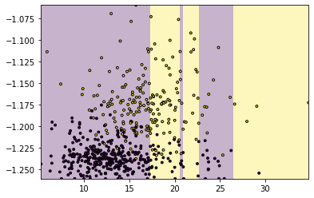

```python
dbplot(txN, ccN, 7)
```

```python
cv = cross_val_score(m, Xn, y, cv=10)
cv.mean()
```

```
0.9208646616541353
```

### 3.

The decision boundary looks different because the numbers have been normalized, and therefore the decision boundaries have moved to represent different numbers. The accuracy of the normalized data is much better.

### 4.

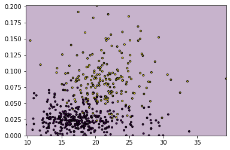

```
0.9261278195488721
```

```python
X = wisc[['texture.mean','concpoints.mean']].values
y = wisc.diagnosis.values
V = np.cov(X, rowvar=False)
m = KNeighborsClassifier(7, metric='mahalanobis', metric_params={"V":V})
_ = m.fit(X, y)
def newdb(j, i ,z):
    y = wisc.diagnosis == "M"
    X = np.column_stack((j, i))
    V = np.cov(X, rowvar=False)
    m = KNeighborsClassifier(7, metric='mahalanobis', metric_params={"V":V})
    e = m.fit(X, y)
    ex1 = np.linspace(j.min(), j.max(), 100)
    ex2 = np.linspace(i.min(), i.min(), 100)
    xx1, xx2 = np.meshgrid(ex1, ex2)
    g = np.column_stack((xx1.ravel(), xx2.ravel()))
    haty = m.predict(g).reshape(100,100)
    _=plt.imshow(haty, extent=(j.min(), j.max(), i.min(), i.max()),
                 aspect = "auto",
                 interpolation="none", origin="lower",
                 alpha=0.3)
    _ = plt.scatter(j,i,c=y, edgecolor="k", s=8)
    _ = plt.show()
newdb(wisc['texture.mean'], wisc['concpoints.mean'], 7)
cv = cross_val_score(m, X, y, cv=10)
cv.mean()
```

### 5.

```python
wisc.columns
```

```
Index(['diagnosis', 'radius.mean', 'texture.mean', 'perimeter.mean',
       'area.mean', 'smoothness.mean', 'compactness.mean', 'concavity.mean',
       'concpoints.mean', 'symmetry.mean', 'fracdim.mean', 'radius.se',
       'texture.se', 'perimeter.se', 'area.se', 'smoothness.se',
       'compactness.se', 'concavity.se', 'concpoints.se', 'symmetry.se',
       'fracdim.se', 'radius.worst', 'texture.worst', 'perimeter.worst',
       'area.worst', 'smoothness.worst', 'compactness.worst',
       'concavity.worst', 'concpoints.worst', 'symmetry.worst',
       'fracdim.worst'],
      dtype='object')
```

#### Regular

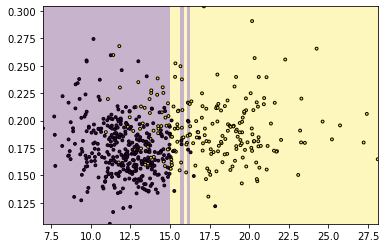

```python
dbplot(wisc['radius.mean'], wisc['symmetry.mean'], 3)
```

```python
X = wisc[['radius.mean','symmetry.mean']].values
y = wisc.diagnosis.values
cv = cross_val_score(m, X, y, cv=10)
cv.mean()
```

```
0.8999686716791981
```

#### Normalized

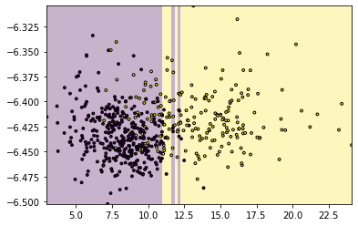

```python
y = wisc.diagnosis.values
m = KNeighborsClassifier(3)
_ = m.fit(X,y)
rmN = (wisc["radius.mean"] - wisc["radius.mean"].mean()/wisc["radius.mean"].std())
syN = (wisc["symmetry.mean"] - wisc["symmetry.mean"].mean()/wisc["symmetry.mean"].std())
dbplot(rmN, syN, 3)
```

```python
X = wisc[['radius.mean','symmetry.mean']].values
Xn = np.empty_like(X)
for i in range(X.shape[1]):
    Xn[:,i] = (X[:,i] - X[:,i].mean())/X[:,i].std()
cv = cross_val_score(m, Xn, y, cv=10)
cv.mean()
```

```
0.8893170426065163
```

#### Mahalnobis

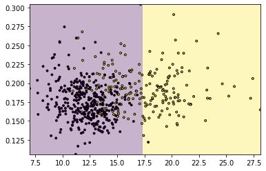

```
0.892951127819549
```

```python
X = wisc[['radius.mean','symmetry.mean']].values
y = wisc.diagnosis.values
V = np.cov(X, rowvar=False)
m = KNeighborsClassifier(7, metric='mahalanobis', metric_params={"V":V})
_ = m.fit(X, y)
newdb(wisc['radius.mean'], wisc['symmetry.mean'], 3)
cv = cross_val_score(m, X, y, cv=10)
cv.mean()
```

### Smoothness mean and compactness mean using 10 nearest-neighbors

#### Regular

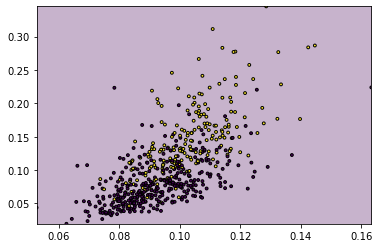

```python
dbplot(wisc['smoothness.mean'], wisc['compactness.mean'], 10)
```

```python
X = wisc[['smoothness.mean','compactness.mean']].values
y = wisc.diagnosis.values
cv = cross_val_score(m, X, y, cv=10)
cv.mean()
```

```
0.787374686716792
```

#### Normalized

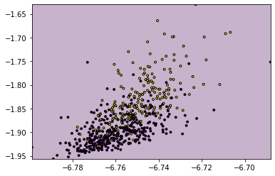

```python
y = wisc.diagnosis.values
m = KNeighborsClassifier(10)
_ = m.fit(X,y)
smN = (wisc["smoothness.mean"] - wisc["smoothness.mean"].mean()/wisc["smoothness.mean"].std())
cpN = (wisc["compactness.mean"] - wisc["compactness.mean"].mean()/wisc["compactness.mean"].std())
dbplot(smN, cpN, 10)
```

```python
X = wisc[['smoothness.mean','compactness.mean']].values
Xn = np.empty_like(X)
for i in range(X.shape[1]):
    Xn[:,i] = (X[:,i] - X[:,i].mean())/X[:,i].std()
cv = cross_val_score(m, Xn, y, cv=10)
cv.mean()
```

```
0.7908208020050126
```

#### Mahalnobis

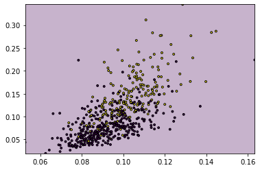

```
0.7961152882205513
```

```python
X = wisc[['smoothness.mean','compactness.mean']].values
y = wisc.diagnosis.values
V = np.cov(X, rowvar=False)
m = KNeighborsClassifier(10, metric='mahalanobis', metric_params={"V":V})
_ = m.fit(X, y)
newdb(wisc['smoothness.mean'], wisc['compactness.mean'], 10)
cv = cross_val_score(m, X, y, cv=10)
cv.mean()
```

## 2. Images: Reduce the Number of Colors

### 1.

[figure not shown]

```python
from matplotlib.image import imread
pixels = imread("../data/a5f8962c478595cbf3b9e7a7a06f3afa.jpg")
ax = plt.subplot(1,1,1)
ax.set_aspect("equal")
_ = plt.imshow(pixels)
_ = plt.show()
```

### 2.

```python
pixels.shape
```

```
(960, 640, 3)
```

```python
M = pixels.reshape((-1,pixels.shape[2]))
print(M.shape)
```

```
(614400, 3)
```

```python
from sklearn.cluster import KMeans
```

```python
m = KMeans(16).fit(M) # cluster the color values
cl = m.predict(M) # find the cluster id for each pixel
centers = m.cluster_centers_ # find the cluster centers (i.e. colors)
print("center color values:\n", centers)
```

```
center color values:
 [[ 75.39612499  66.45049888  59.76885297]
 [227.71020285 231.97745268 231.33950431]
 [134.60508453 131.64087169 126.27500913]
 [ 38.02138648  38.48392976  33.98693724]
 [249.15307302 235.10117406  82.07711465]
 [181.12433259 182.042144   185.03260588]
 [ 44.83530545  82.49422124 147.18505779]
 [250.31334549 252.89502875 252.80507707]
 [118.31264584  86.25683822  68.86177729]
 [161.10403121 112.29439387  90.5437798 ]
 [152.74641745 149.88119974 146.7884373 ]
 [207.41243368 210.54144561 213.90190156]
 [118.37859749 115.41444646 109.25872941]
 [219.86951066 188.75491426  55.11013523]
 [ 61.21972347 116.2655339  202.8145927 ]
 [219.93991266  54.78061135  64.90951965]]
```

[figure not shown]

```python
compressed = centers[cl]/255 # normalize to between 0 and 1
compressed = compressed.reshape(pixels.shape)
# make it back to NxM array
ax = plt.subplot(1,1,1)
ax.set_aspect("equal")
_ = plt.imshow(compressed)
_ = plt.show()
```

- a. The shape of the pixels represents the number of rows, columns, and channels of color
- b. M represents the columns for each color channel, this numebr is derrived from multiplying the columns by rows from the shape described above.
- c. cl[?] is finding the cluster id for each pixel.
- d. Center color value coloumns represent the RGB colorspace, it shows what color pixels are at certain locations.
- e. There are 16 different center color values becuase we turned this image into one that only has 16 color values.

### 3.

#### 2 colors

```
(614400, 3)
center color values:
 [[121.5447237  112.97984312 107.32674446]
 [227.15253223 228.48178077 215.13152419]]
```

[figure not shown]

```python
pixels = imread("../data/a5f8962c478595cbf3b9e7a7a06f3afa.jpg")
ax = plt.subplot(1,1,1)
ax.set_aspect("equal")
_ = plt.imshow(pixels)
M = pixels.reshape((-1,pixels.shape[2]))
print(M.shape)
def colors(e):
    m = KMeans(e).fit(M) # cluster the color values
    cl = m.predict(M) # find the cluster id for each pixel
    centers = m.cluster_centers_ # find the cluster centers (i.e. colors)
    print("center color values:\n", centers)
    compressed = centers[cl]/255 # normalize to between 0 and 1
    compressed = compressed.reshape(pixels.shape)
    # make it back to NxM array
    ax = plt.subplot(1,1,1)
    ax.set_aspect("equal")
    _ = plt.imshow(compressed)
    _ = plt.show()
colors(2)
```

#### 4 colors

```
(614400, 3)
center color values:
 [[242.37042258 223.87510489  76.55174034]
 [138.11645324 131.84112378 129.27981348]
 [228.24936934 231.45874401 232.15375708]
 [ 74.72168347  62.24765617  56.85919864]]
```

[figure not shown]

```python
pixels = imread("../data/a5f8962c478595cbf3b9e7a7a06f3afa.jpg")
ax = plt.subplot(1,1,1)
ax.set_aspect("equal")
_ = plt.imshow(pixels)
M = pixels.reshape((-1,pixels.shape[2]))
print(M.shape)
colors(4)
```